# Using Web APIs in R

January 13, 2017

## Overview

- Intro and basic assumptions
- Tools for accessing APIs
- Lots of examples
- Practical application
- Recap
- What next?

## Assumptions

- A general interest in data, its acquisition, and its visualization
- Familiarity with R
- A basic understanding of HTTP communication concepts, if not the syntax

## Assumptions

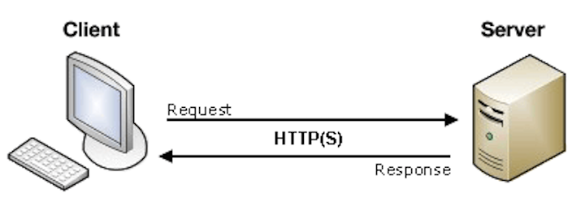

.

Request:

```
curl "http://www.omdbapi.com/?t=clue&r=json"
```

Response:

```
{"Title":"Clue","Year":"1985","Rated":"PG", ...}
```

## What is an API

### … and why would I want to use one?

- API: Application Programming Interface
- APIs allow you to access a program from within another program
- For data retrieval, we usually mean APIs based on HTTP communication, a.k.a. web APIs
- APIs usually provide read and/or write access to data stores
- APIs allow you to access data on an ongoing basis

## Tools for accessing web APIs from R

- packages that wrap API calls for a given service
  - aws.s3, RGoogleAnalytics, acs, etc.
- **httr** for making requests
- **jsonlite, xml2** for parsing the response

*And once you have the data…*

- **dplyr, tidyr, lubridate**, etc. for data wrangling

## Lots of examples

**Example scripts are available in a repo I'll share at the end**

.

OMDB - http://www.omdbapi.com/

SWAPI - https://swapi.co/

Twitter (OAuth1) - https://api.twitter.com

GitHub (OAuth2) - https://api.github.com

## Practical application

*Support Ticket Reports, in Two Parts*

1. R script to get support ticket data via API
   - Pages through data and puts it all in a single dataframe
   - Filters, tidies, and flattens the raw data into a nice, easy-to-use rectangle
   - Saves the tidied data to an S3 bucket
   - Deployed to RStudio Connect; scheduled to poll the API and update the datastore automatically
2. Various applications and Rmd documents pull the data from S3
   - Visualizations for tickets by product, OS, priority, category/feature, etc.
   - We use this data to target product improvements, documentation enhancements, process improvements

Support Ticket Demo

## What next?

- More on APIs and HTTP:
  - https://zapier.com/learn/apis/chapter-1-introduction-to-apis/
  - https://www.ntu.edu.sg/home/ehchua/programming/webprogramming/HTTP_Basics.html
- More on the tools:
  - `help(package=httr)`
  - https://cran.r-project.org/web/packages/httr/vignettes/quickstart.html
  - http://github.com/hadley/httr/tree/master/demo
  - https://cran.r-project.org/web/packages/jsonlite/vignettes/json-apis.html
  - https://cran.r-project.org/web/packages/httr/vignettes/api-packages.html

–

- https://github.com/ajmcoqui/webAPIsR
- amanda@rstudio.com
- Thank you!